# SI 618 WN 2018 - Homework 4: Using the Spark RDD API to analyze bigrams in text

### NOTE: If your PySpark installation isn't working please plan to attend office hours or set up an appointment with Kai (Mac or Windows) or Dr. Teplovs (Mac) as soon as possible.

## Objectives

1. To gain familiarity with PySpark
2. To learn the basics of the Spark RDD API
3. To get experience finding and downloading data

## Please fill in...

### * Your name: Raphael Ku

### * People you worked with: I worked by myself

## Submission Instructions:

Please turn in this Jupyter notebook file (in both .ipynb and .html formats) **and the text file that contains the text you analyzed** via Canvas.

## Overview

This project is designed to give you a basic familiarity with the Apache Spark RDD API.

**Your first task** is to run the next code cell in this notebook, as is, (without modification) and confirm that everything is working.

Your second and main task is to modify the word_count_v2.ipynb file in Lab 4 to create a si618-hw4-YOUR_UNIQNAME, which counts the number of bigrams within the corpus. At the conclusion of its execution, it should output three pieces of information:

1. the total number of bigrams
2. the 20 most common bigrams
3. the minimum number of bigrams required to add up to 10% of all bigrams

```python
import re
import pyspark
from pyspark import SparkContext
sc = SparkContext.getOrCreate()

totc = ["It was the best of times",
    "it was the worst of times",
    "it was the age of wisdom",
    "it was the age of foolishness",
    "it was the epoch of belief",
    "it was the epoch of incredulity",
    "it was the season of Light",
    "it was the season of Darkness",
    "it was the spring of hope",
    "it was the winter of despair",
    "we had everything before us",
    "we had nothing before us",
    "we were all going direct to Heaven",
    "we were all going direct the other way"]

WORD_RE = re.compile(r"\b[\w']+\b")

input_text = sc.parallelize(totc)
word_counts_sorted = input_text.flatMap(lambda line: WORD_RE.findall(line)) \
    .map(lambda word: (word, 1)) \
    .reduceByKey(lambda accumulator, value: accumulator + value) \
    .sortBy(lambda x: x[1], ascending = False)

top10_sorted = word_counts_sorted.take(10)
top10_sorted
```

```
[('the', 11),
 ('of', 10),
 ('was', 10),
 ('it', 9),
 ('we', 4),
 ('age', 2),
 ('times', 2),
 ('going', 2),
 ('us', 2),
 ('season', 2)]
```

## Bigram Analysis

Bigrams are pairs of continguous words. For example, consider the text "The quick brown fox". The bigrams in that text are: (The, quick), (quick, brown), (brown,fox).

You should be able to use the above code as a starting point, with the main difference being that you will be extracting pairs of words rather than single words.

Here are the steps you need to include:

1. Find and download a text file from the Gutenberg Project. Please select a book written in English and download the plain text version (i.e. the .txt file).
2. Normalize the text by converting it to lowercase.
3. Extract all bigrams from the text. Don’t try to get fancy: just take all the pairs of words from each line of your text file
4. Perform a mapping to yield a count of one for each bigram (e.g. (("the", "quick"), 1)).
5. Reduce this list of bigrams with count of one to counts of bigrams (e.g. (("the", "quick"), 312)).
6. Sort to determine the most frequent and total number of bigrams.
7. Report the total number of bigrams, the top 20 most common bigrams and the minimum number of bigrams required to add up to 10% of all bigrams.

### Step 1a: Find and download a text file

Go to Project Gutenberg (http://www.gutenberg.org) and find a book written in English that you think sounds interesting. Download the plain text (.txt) version of the book.

### Step 1b: Load the text file into Spark

```python
text_file_name = "CountMC.txt"
input_text = sc.textFile(text_file_name)
```

### Steps 2 and 3: Normalize text and extract bigrams

Note: there are many ways to accomplish this. We recommend you create a function that both creates bigrams and normalizes text. The following template code assumes this is the approach you are planning to take.

```python
def normalize_and_extract_bigrams(line):
    towords = line.lower()
    towords = re.findall('\w+', towords)
    words = [(towords[x], towords[x+1]) for x in range(len(towords)-1)]
    return words
```

```python
bigrams1 = input_text.flatMap(normalize_and_extract_bigrams)
bigrams1.take(20)
```

```
[('project', 'gutenberg'),
 ('gutenberg', 's'),
 ('s', 'the'),
 ('the', 'count'),
 ('count', 'of'),
 ('of', 'monte'),
 ('monte', 'cristo'),
 ('cristo', 'by'),
 ('by', 'alexandre'),
 ('alexandre', 'dumas'),
 ('dumas', 'père'),
 ('this', 'ebook'),
 ('ebook', 'is'),
 ('is', 'for'),
 ('for', 'the'),
 ('the', 'use'),
 ('use', 'of'),
 ('of', 'anyone'),
 ('anyone', 'anywhere'),
 ('anywhere', 'at')]
```

### Step 4: Map the bigrams to key-value pairs where the key is the bigram and the value is 1

```python
bigrams2 = bigrams1.map(lambda x: (x, 1)) # Replace the ... with the appropriate code
```

### Step 5: Reduce the (word,1) key-value pairs to give you counts of each bigram

```python
bigrams3 = bigrams2.reduceByKey(lambda x, y: x+y)
bigrams3.take(5)
# Replace ... with your code
```

```
[(('project', 'gutenberg'), 76),
 (('gutenberg', 's'), 2),
 (('count', 'of'), 204),
 (('dumas', 'père'), 4),
 (('this', 'ebook'), 4)]
```

### Step 6: Sort the resulting RDD by value in descending order

```python
bigrams_sorted = bigrams3.sortBy(lambda x: x[1], ascending=False)
bigrams_sorted.take(5)
```

```
[(('of', 'the'), 2968),
 (('in', 'the'), 1721),
 (('to', 'the'), 1476),
 (('the', 'count'), 1161),
 (('monte', 'cristo'), 1054)]
```

### Step 7: Report the required values

1. the total number of bigrams
2. the 20 most common bigrams
3. the minimum number of bigrams required to add up to 10% of all bigrams

```python
# Total number of bigrams (Total >> Number of unique bigrams)
print('The Count of Monte Cristo has {} unique bigrams'.format(bigrams_sorted.count()))
```

```
The Count of Monte Cristo has 154200 unique bigrams
```

```python
# Total number of bigrams (Total >> Count of ALL bigrams)
aa = bigrams_sorted.values().sum()
print('The Count of Monte Cristo has {} total bigrams'.format(aa))
```

```
The Count of Monte Cristo has 426284 total bigrams
```

```python
# Top 20 common bigrams
bigrams_sorted.take(20)
```

```
[(('of', 'the'), 2968),
 (('in', 'the'), 1721),
 (('to', 'the'), 1476),
 (('the', 'count'), 1161),
 (('monte', 'cristo'), 1054),
 (('on', 'the'), 1028),
 (('at', 'the'), 1025),
 (('it', 'is'), 967),
 (('i', 'have'), 843),
 (('and', 'the'), 831),
 (('said', 'the'), 774),
 (('i', 'am'), 760),
 (('he', 'had'), 722),
 (('it', 'was'), 687),
 (('of', 'a'), 646),
 (('you', 'are'), 626),
 (('of', 'his'), 617),
 (('with', 'the'), 593),
 (('to', 'be'), 589),
 (('do', 'you'), 582)]
```

```python
# Bigrams needed to 10% of bigrams (426284)
iter = 1
current = 0
while current < aa*0.1:
    current = sum(bigrams_sorted.values().take(iter))
    iter += 1
```

```python
print('To get 10% of total bigrams (42629), you need a minimum of {} bigrams'.format(iter))
```

[output not shown]

# END OF HOMEWORK 4

### Above and Beyond

I believe my work below merits extra credit as it attempts to explore common bigrams used in both 'The Count of Monte Cristo', and 'The Three Musketeers'. The first part explores the number of unique bigrams shared by the 2 books (33,049 bigrams), using RDD intersection to determine this.

The second part focuses on finding the number of shared total bigrams for the 2 books, exploring which combination of words led to the highest frequencies. To do this, I used the 99.9th percentile of the shared total bigrams as reference, since most word combinations will be 0. I then laid the frequency of each bigram falling under this filter in a heatmap, indicating that bigrams with the second word as 'the' had the highest common frequency between the two books.

```python
import pandas as pd
import seaborn as sns
%matplotlib inline
```

```python
musketeers = sc.textFile('Count-Musk.txt')
musketeers1 = musketeers.flatMap(normalize_and_extract_bigrams)
musketeers2 = musketeers1.map(lambda x: (x, 1))
musketeers3 = musketeers2.reduceByKey(lambda x, y: x+y)
```

```python
commonbigrams = bigrams1.intersection(musketeers1)
commonbigrams.take(5)
```

```
[('project', 'gutenberg'),
 ('use', 'of'),
 ('of', 'anyone'),
 ('at', 'no'),
 ('cost', 'and')]
```

```python
print('Between the Count of Monte Cristo and The Three Musketeers, \
there are {} distinctly unique bigrams'.format(commonbigrams.count()))
```

```
Between the Count of Monte Cristo and The Three Musketeers, there are 33049 distinctly unique bigrams
```

```python
print('Unique bigrams in Count of Monte Cristo: {}\n\
Unique bigrams in The Three Musketeers: {}'.format(bigrams1.distinct().count(), musketeers1.distinct().count()))
```

```
Unique bigrams in Count of Monte Cristo: 154200
Unique bigrams in The Three Musketeers: 83628
```

```python
mixed = musketeers3.join(bigrams3)
sharedbigrams = {bigram[0]: min(bigram[1][0], bigram[1][1]) for bigram in mixed.collect()}
```

```python
sharedbigrams
```

[output not shown]

[output cut: 946 more lines]

[output not shown]

```python
sharedbigramdf = pd.DataFrame({'Bigram':list(sharedbigrams.keys()), 'Count':list(sharedbigrams.values())})
sharedbigramdf['1st_word'] = sharedbigramdf.Bigram.map(lambda x: x[0])
sharedbigramdf['2nd_word'] = sharedbigramdf.Bigram.map(lambda x: x[1])
```

```python
filtered = sharedbigramdf[sharedbigramdf.Count >= 212]
sharedbigramdf.Count.quantile(0.999)
```

```
211.95200000000477
```

```python
matrix =filtered.pivot(index='1st_word', columns='2nd_word', values='Count').fillna(0)
matrix
```

| 2nd_word 1st_word | a | am | are | be | de | had | have | he | his | i | is | not | the | was | will | you | young |
| --- | --- | --- | --- | --- | --- | --- | --- | --- | --- | --- | --- | --- | --- | --- | --- | --- | --- |
| and | 0.0 | 0.0 | 0.0 | 0.0 | 0.0 | 0.0 | 0.0 | 0.0 | 0.0 | 237.0 | 0.0 | 0.0 | 391.0 | 0.0 | 0.0 | 0.0 | 0.0 |
| at | 0.0 | 0.0 | 0.0 | 0.0 | 0.0 | 0.0 | 0.0 | 0.0 | 0.0 | 0.0 | 0.0 | 0.0 | 550.0 | 0.0 | 0.0 | 0.0 | 0.0 |
| by | 0.0 | 0.0 | 0.0 | 0.0 | 0.0 | 0.0 | 0.0 | 0.0 | 0.0 | 0.0 | 0.0 | 0.0 | 295.0 | 0.0 | 0.0 | 0.0 | 0.0 |
| did | 0.0 | 0.0 | 0.0 | 0.0 | 0.0 | 0.0 | 0.0 | 0.0 | 0.0 | 0.0 | 0.0 | 213.0 | 0.0 | 0.0 | 0.0 | 0.0 | 0.0 |
| do | 0.0 | 0.0 | 0.0 | 0.0 | 0.0 | 0.0 | 0.0 | 0.0 | 0.0 | 0.0 | 0.0 | 0.0 | 0.0 | 0.0 | 0.0 | 215.0 | 0.0 |
| for | 0.0 | 0.0 | 0.0 | 0.0 | 0.0 | 0.0 | 0.0 | 0.0 | 0.0 | 0.0 | 0.0 | 0.0 | 253.0 | 0.0 | 0.0 | 0.0 | 0.0 |
| he | 0.0 | 0.0 | 0.0 | 0.0 | 0.0 | 400.0 | 0.0 | 0.0 | 0.0 | 0.0 | 0.0 | 0.0 | 0.0 | 284.0 | 0.0 | 0.0 | 0.0 |
| i | 0.0 | 401.0 | 0.0 | 0.0 | 0.0 | 0.0 | 408.0 | 0.0 | 0.0 | 0.0 | 0.0 | 0.0 | 0.0 | 0.0 | 279.0 | 0.0 | 0.0 |
| in | 280.0 | 0.0 | 0.0 | 0.0 | 0.0 | 0.0 | 0.0 | 0.0 | 226.0 | 0.0 | 0.0 | 0.0 | 846.0 | 0.0 | 0.0 | 0.0 | 0.0 |
| it | 0.0 | 0.0 | 0.0 | 0.0 | 0.0 | 0.0 | 0.0 | 0.0 | 0.0 | 0.0 | 429.0 | 0.0 | 0.0 | 332.0 | 0.0 | 0.0 | 0.0 |
| m | 0.0 | 0.0 | 0.0 | 0.0 | 243.0 | 0.0 | 0.0 | 0.0 | 0.0 | 0.0 | 0.0 | 0.0 | 0.0 | 0.0 | 0.0 | 0.0 | 0.0 |
| of | 351.0 | 0.0 | 0.0 | 0.0 | 0.0 | 0.0 | 0.0 | 0.0 | 364.0 | 0.0 | 0.0 | 0.0 | 1589.0 | 0.0 | 0.0 | 0.0 | 0.0 |
| on | 0.0 | 0.0 | 0.0 | 0.0 | 0.0 | 0.0 | 0.0 | 0.0 | 0.0 | 0.0 | 0.0 | 0.0 | 360.0 | 0.0 | 0.0 | 0.0 | 0.0 |
| said | 0.0 | 0.0 | 0.0 | 0.0 | 0.0 | 0.0 | 0.0 | 0.0 | 0.0 | 0.0 | 0.0 | 0.0 | 300.0 | 0.0 | 0.0 | 0.0 | 0.0 |
| that | 0.0 | 0.0 | 0.0 | 0.0 | 0.0 | 0.0 | 0.0 | 240.0 | 0.0 | 221.0 | 212.0 | 0.0 | 222.0 | 0.0 | 0.0 | 0.0 | 0.0 |
| the | 0.0 | 0.0 | 0.0 | 0.0 | 0.0 | 0.0 | 0.0 | 0.0 | 0.0 | 0.0 | 0.0 | 0.0 | 0.0 | 0.0 | 0.0 | 0.0 | 240.0 |
| to | 0.0 | 0.0 | 0.0 | 384.0 | 0.0 | 0.0 | 0.0 | 0.0 | 0.0 | 0.0 | 0.0 | 0.0 | 727.0 | 0.0 | 0.0 | 0.0 | 0.0 |
| with | 295.0 | 0.0 | 0.0 | 0.0 | 0.0 | 0.0 | 0.0 | 0.0 | 0.0 | 0.0 | 0.0 | 0.0 | 316.0 | 0.0 | 0.0 | 0.0 | 0.0 |
| you | 0.0 | 0.0 | 357.0 | 0.0 | 0.0 | 0.0 | 253.0 | 0.0 | 0.0 | 0.0 | 0.0 | 0.0 | 0.0 | 0.0 | 0.0 | 0.0 | 0.0 |

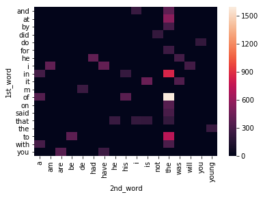

```python
sns.heatmap(matrix)
```